# Study of the Exponential Distribution

Valerii Podymov

October 20, 2015

## Overview

The goal of this project is to investigate the exponential distribution and compare it with the Central Limit Theorem. The exponential distribution will be simulated in R with rexp(n, lambda) where lambda is the rate parameter. The parameter lambda will be set to 0.2 for all of the simulations. The distribution of averages of 40 exponentials will be investigated in a thousand simulations.

## Simulations

```r
# Define constants
lambda <- 0.2   # lambda parameter of rthe exponential distribution
nexps <- 40     # the number of exponetials
nsims <- 1000   # the number of simulations

# Set the seed to provide reproducibility of results
set.seed(11111)

# Simulate the distribution of 1000 averages of 40 random exponentials
mns = NULL
for (i in 1 : nsims)
    mns = c(mns, mean(rexp(nexps, rate = lambda)))
```

## Comparison of the Theoretical Mean with the Sample Mean

The theoretical mean $\mu$ of the averages of 40 exponential distributions of rate $\lambda$ is $\mu= \frac{1}{\lambda}$. And in our example its value is

```r
mu <- 1/lambda
mu
```

```
## [1] 5
```

The sample value of the mean is

```r
mean(mns)
```

```
## [1] 5.020674
```

And it is very close to the theoretical value.

## Comparison of the Theoretical Variance with the Sample Variance

The standard error $s$ of the mean of $n$ exponential distributions of rate $\lambda$ is $s = \frac{\sigma}{\sqrt{n}} = \frac{1/\lambda}{\sqrt{n}}$

And consequently the variance $Var$ of the mean is $Var = s^2$

```r
std_err <- 1/lambda/sqrt(nexps)
Var <- std_err^2
Var
```

```
## [1] 0.625
```

The sample value of the variance is

```r
var(mns)
```

```
## [1] 0.6304973
```

And it is also quite close to the theoretical value.

## Results

The Central Limit Theorem states that the $averages$ of iid samples are approximately normal with distributions centered at the population mean with standard deviation equal to the standard error of the mean.

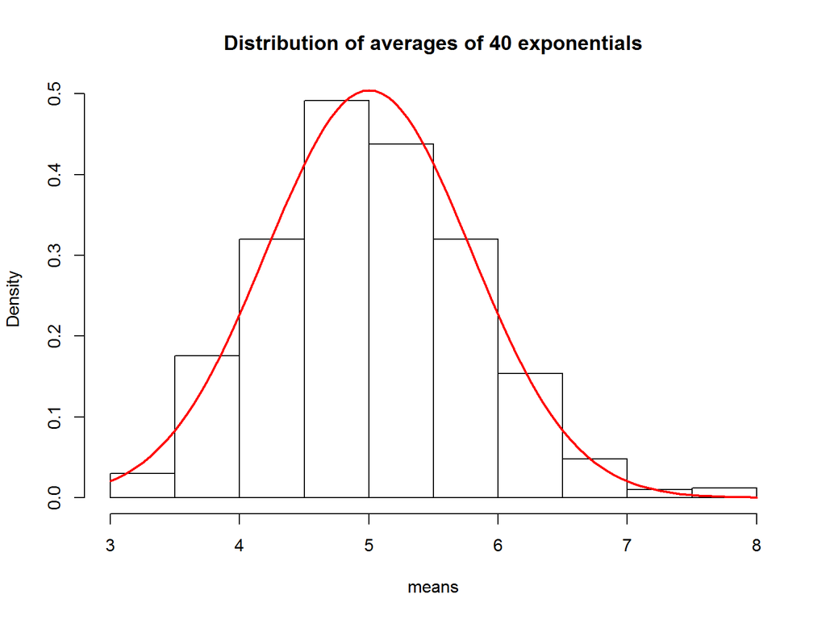

As we can see from the histogram above, the shape of the distribution of the averages of 40 exponentials is approximately normal. The density curve of the normal distribution $N(\mu = 5, \frac{\sigma^2}{n} = 0.625)$ is shown by red color.

For a contrast, the distribution of 1000 random exponentials with $\lambda = 0.2$ is shown on the histogram below.

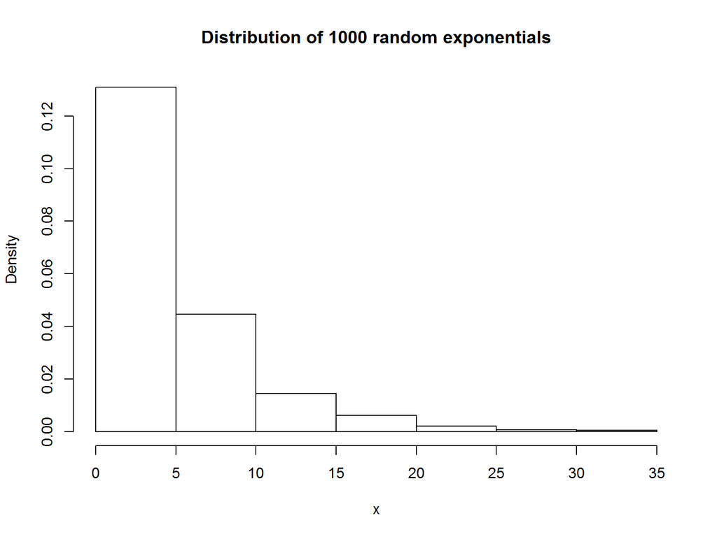

As we can see, the last distribution is far from Gaussian.